# Fitting Two-Way Factorial Designs

November 9, 2021

## Announcements

- HW 6 grades posted; MP1 grades are (mostly) posted
- HW 7 posted and due Friday Nov 12 11:55p
  - Find a research article that uses ANOVA
- In-person Office hours (Bass 412)
  - Wed (tomorrow) 10:50-12:05p
- Zoom Office hours
  - Friday 12:15-3p
  - Slots open on Thurs morning
- Where to get HW help
  - [Spinelli center](https://www.smith.edu/qlc/tutoring.html) tutoring Sun-Thurs 7-9p, Sabin-Reed 301.
  - Post questions to #homework7-questions channel on Slack!
  - Direct message me on Slack.
- Applications open for DSC-WAV (more info [here](https://dsc-wav.github.io/www/students.html#Eligibility))
  - Due tomorrow

## SDS Biostatistics Job Candidates

1. Tea with candidates 3:30-4:30 p.m. ([sign-up here!](https://docs.google.com/spreadsheets/d/1uuFRI2TPpYdSWXImIFO9JaXkXgHTihuBtqXOr3NmbjQ/edit#gid=0))
2. Research talks with grab-and-go lunches (12:25-1:20 p.m.)
3. Teaching demonstrations (5:00-6:00 p.m.)

**Friday November 12, 2021**: Kaitlyn Cook “Statistical Methods for Cluster-Randomized Infectious Disease Prevention Trial”. Research talk: Ford 240. Teaching talk: Sabin-Reed 301

**Monday November 15, 2021**: Anny-Claude Joseph “The Timing of Geographic Power”. Research talk: Ford 240. Teaching talk: Sabin-Reed 301

**Wednesday November 17, 2021**: Jacob Fiksel “Generalized Bayes Quantification Learning with Applications to Mortality Surveillance”. Research talk: McConnell 103. Teaching talk: Sabin-Reed 301

## Agenda

1. MP2 Assignment
2. Two-Way Factorial Design (continued)
   - More interactions!
   - Fitting the ANOVA model

## MP2 Assignment

- MP2 instructions
- MP2 [group selection survey](https://docs.google.com/forms/d/e/1FAIpQLSdAnm-YO99CPLIkkpaciS9_e0V04bCRFCVsVg0mdHAIOvSJtQ/viewform?usp=sf_link)

## Interaction Graphs

For each of the following interaction graphs, answer the following questions with **YES** or **NO**.

1. Is there a main effect of B12?
2. Is there a main effect of antibiotics?
3. Is there an interaction between B12 and antibiotics?

## Practice 1

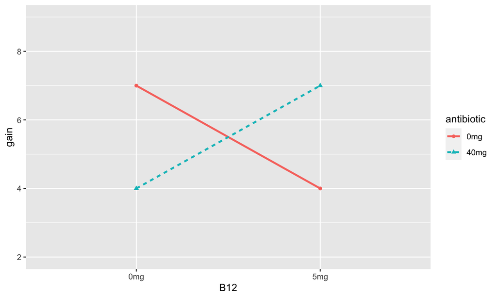

## Practice 1

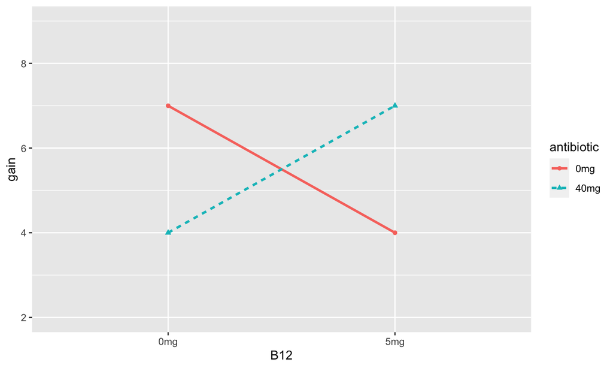

1. NO
2. NO
3. YES

## Practice 2

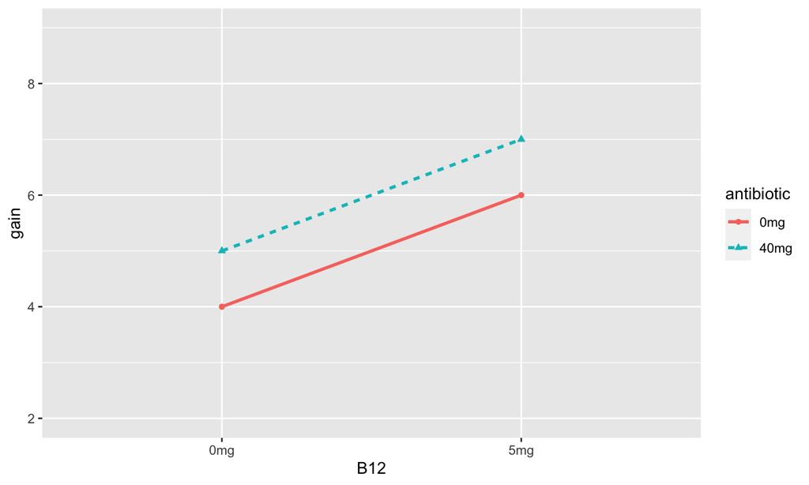

## Practice 2

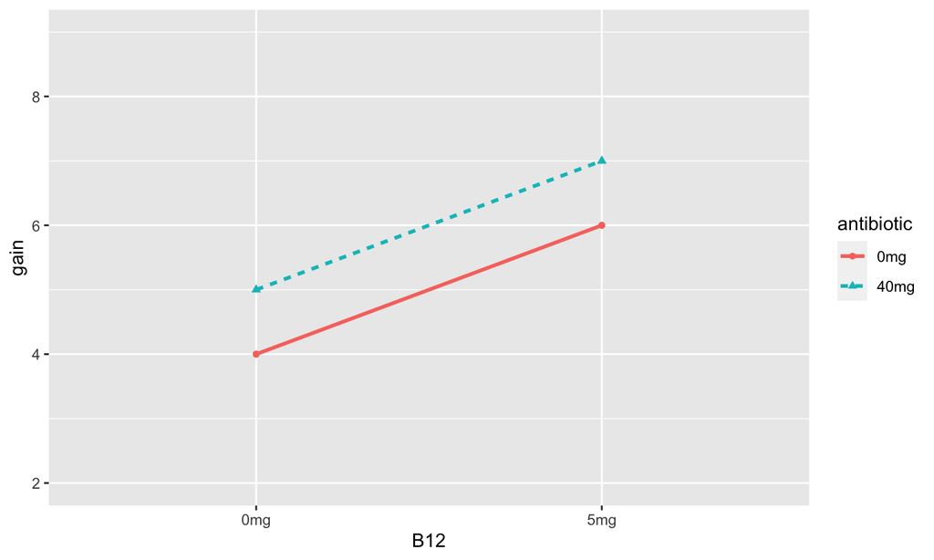

1. YES
2. YES
3. NO

## Practice 3

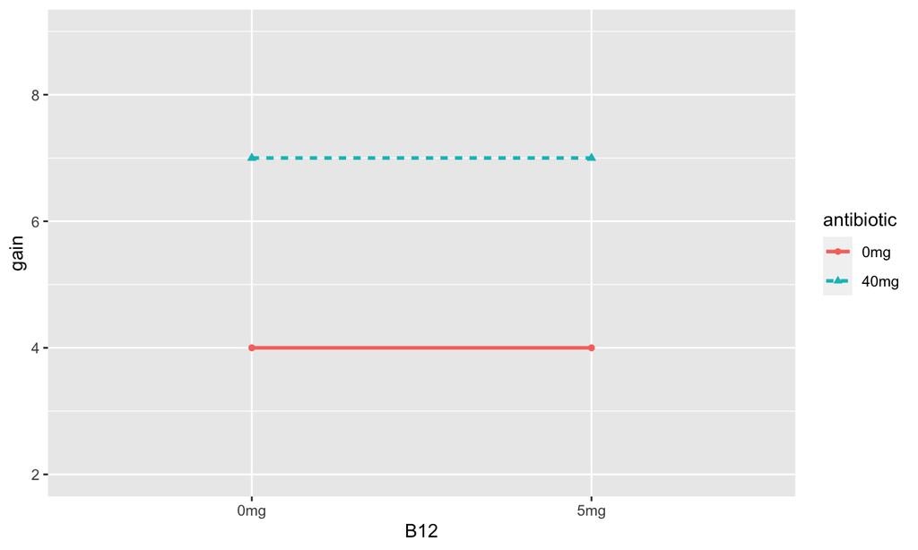

## Practice 3

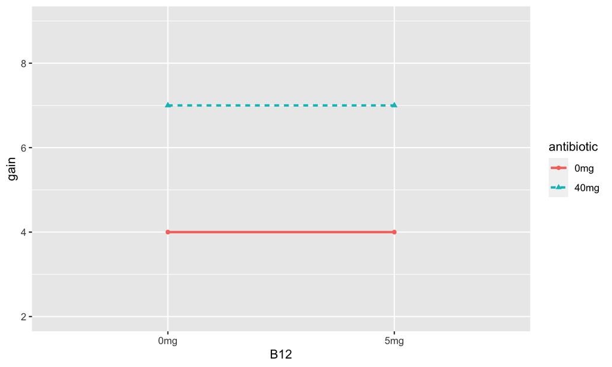

1. NO
2. YES
3. NO

## Two-Way Factorial Design Formulas

\[{y}_{ijk}={\mu}+{\alpha}_{i}+{\beta}_{j}+{\alpha\beta}_{ij}+{e}_{ijk}\]

- Where \(i\), from 1 to \(a\), is the level of the first factor,
- \(j\), from 1 to \(b\), is the level of the second factor,
- and \(k\), from 1 to \(n\), is the observation in each cell.

## Sum of Squares (SS)

\[{SS}_{A} = \sum_{i=1}^{a}bn(\bar{y}_{i..}-\bar{y}_{…})^{2}\]

\[{SS}_{B} = \sum_{j=1}^{b}an(\bar{y}_{.j.}-\bar{y}_{…})^{2}\]

\[{SS}_{AB} = n\sum_{i=1}^{a}\sum_{j=1}^{b}(\bar{y}_{ij.}-\bar{y}_{i..}-\bar{y}_{.j.}+\bar{y}_{…})^{2}\]

\[{SS}_{E} = \sum_{i=1}^{a}\sum_{j=1}^{b}\sum_{k=1}^{n}({y}_{ijk}-\bar{y}_{ij.})^{2}\]

## Degrees of Freedom (df)

\[{df}_{A}=a-1\]

\[{df}_{B}=b-1\]

\[{df}_{AB}=(a-1)(b-1)\]

\[{df}_{E}=ab(n-1)\]

## Mean Squares (MS)

\[{MS}_{A}=\frac{{SS}_{A}}{{df}_{A}}\]

\[{MS}_{B}=\frac{{SS}_{B}}{{df}_{B}}\]

\[{MS}_{AB}=\frac{{SS}_{AB}}{{df}_{AB}}\]

\[{MS}_{E}=\frac{{SS}_{E}}{{df}_{E}}\]

## Three Research Questions, Three F-ratios

1. Is there a significant main effect of factor A?
2. Is there a significant main effect of factor B?
3. Is there an significant interaction between factor A and factor B?

## F-ratios and the F-distribution

The ultimate statistics we want to calculate is Variability in treatment effects/Variability in residuals. The F-ratio.

\[F = \frac{{MS}_{A}}{{MS}_{E}}\]

\[F = \frac{{MS}_{B}}{{MS}_{E}}\]

\[F = \frac{{MS}_{AB}}{{MS}_{E}}\]

## ANOVA Source Table for Two-Way Factorial

\[{y}_{ijk}={\mu}+{\alpha}_{i}+{\beta}_{j}+{\alpha\beta}_{ij}+{e}_{ijk}\]

| Source | SS | df | MS | F |
| --- | --- | --- | --- | --- |
| Treatment A | \(\sum_{i=1}^{a}bn(\bar{y}_{i..}-\bar{y}_{…})^{2}\) | \(a-1\) | \(\frac{{SS}_{A}}{{df}_{A}}\) | \(\frac{{MS}_{A}}{{MS}_{E}}\) |
| Treatment B | \(\sum_{j=1}^{b}an(\bar{y}_{.j.}-\bar{y}_{…})^{2}\) | \(b-1\) | \(\frac{{SS}_{B}}{{df}_{B}}\) | \(\frac{{MS}_{B}}{{MS}_{E}}\) |
| Interaction AB | \(n\sum_{i=1}^{a}\sum_{j=1}^{b}(\bar{y}_{ij.}-\bar{y}_{i..}-\bar{y}_{.j.}+\bar{y}_{…})^{2}\) | \((a-1)(b-1)\) | \(\frac{{SS}_{AB}}{{df}_{AB}}\) | \(\frac{{MS}_{AB}}{{MS}_{E}}\) |
| Error | \(\sum_{i=1}^{a}\sum_{j=1}^{b}\sum_{k=1}^{n}({y}_{ijk}-\bar{y}_{ij.})^{2}\) | \(ab(n-1)\) | \(\frac{{SS}_{E}}{{df}_{E}}\) |  |

## Two-Way Factorial in R

[See Two-Way Factorial code](https://randilgarcia.github.io/sds290fall21/lectures/09_two-way_fac_inR.Rmd)